# Travel_Insurance

Enigma

7/19/2021

## Defining the metric of success

## Data Relevance

The dataset can be sourced from here (“https://www.kaggle.com/tejashvi14/travel-insurance-prediction-data/tasks”)

## The glossary of the data is as follows:

- Age - Age Of The Customer
- Employment Type - The Sector In Which Customer Is Employed
- Graduate or not - Whether The Customer Is College Graduate Or Not
- Annual Income - The Yearly Income Of The Customer In Indian Rupees[Rounded To Nearest 50 Thousand Rupees]
- Family Members - Number Of Members In Customer’s Family
- Chronic Disease - Whether The Customer Suffers From Any Major Disease Or Conditions Like Diabetes/High BP or Asthma,etc.
- Frequent Flyer - Derived Data Based On Customer’s History Of Booking Air Tickets On At least 4 Different Instances In The Last 2 Years[2017-2019].
- Ever Traveled Abroad- Has The Customer Ever Traveled To A Foreign Country[Not Necessarily Using The Company’s Services]
- Travel Insurance - Did The Customer Buy Travel Insurance Package During Introductory Offering Held In The Year 2019.

## Loading the libraries

```r
library(e1071)
library(Rtsne)
library(FSelector)
library(psych)
library(ggplot2)
library(tidyverse)
library(CatEncoders)
library(gridExtra)
library(hrbrthemes)
library(dplyr)
library(rpart)
library(rpart.plot)
library(party)#function ctree
library(caret)#classification and regression training
library(MLmetrics)
library(modelr)
library(broom)
library(superml)
library(randomForest)
library(ROSE)
library(ParamHelpers)
library(mlr)
library(class)
library(tidymodels)
library(discrim)
library(ramify)
library(car)
library(factoextra)
library(NbClust)
library(mclust)
library(clustvarsel)
library(dendextend)
library(cluster)
library(xgboost)
```

## Data Sourcing

```r
travel<- read.csv("C:/Users/NATE/Downloads/TravelInsurancePrediction.csv")
head(travel)
```

```
##   X Age              Employment.Type GraduateOrNot AnnualIncome FamilyMembers
## 1 0  31            Government Sector           Yes       400000             6
## 2 1  31 Private Sector/Self Employed           Yes      1250000             7
## 3 2  34 Private Sector/Self Employed           Yes       500000             4
## 4 3  28 Private Sector/Self Employed           Yes       700000             3
## 5 4  28 Private Sector/Self Employed           Yes       700000             8
## 6 5  25 Private Sector/Self Employed            No      1150000             4
##   ChronicDiseases FrequentFlyer EverTravelledAbroad TravelInsurance
## 1               1            No                  No               0
## 2               0            No                  No               0
## 3               1            No                  No               1
## 4               1            No                  No               0
## 5               1           Yes                  No               0
## 6               0            No                  No               0
```

## Checking the Data

```r
#checking the structure of the dataset
str(travel)
```

```
## 'data.frame':    1987 obs. of  10 variables:
##  $ X                  : int  0 1 2 3 4 5 6 7 8 9 ...
##  $ Age                : int  31 31 34 28 28 25 31 31 28 33 ...
##  $ Employment.Type    : chr  "Government Sector" "Private Sector/Self Employed" "Private Sector/Self Employed" "Private Sector/Self Employed" ...
##  $ GraduateOrNot      : chr  "Yes" "Yes" "Yes" "Yes" ...
##  $ AnnualIncome       : int  400000 1250000 500000 700000 700000 1150000 1300000 1350000 1450000 800000 ...
##  $ FamilyMembers      : int  6 7 4 3 8 4 4 3 6 3 ...
##  $ ChronicDiseases    : int  1 0 1 1 1 0 0 0 1 0 ...
##  $ FrequentFlyer      : chr  "No" "No" "No" "No" ...
##  $ EverTravelledAbroad: chr  "No" "No" "No" "No" ...
##  $ TravelInsurance    : int  0 0 1 0 0 0 0 1 1 0 ...
```

```r
dim(travel)
```

```
## [1] 1987   10
```

```r
sapply(travel,class)
```

```
##                   X                 Age     Employment.Type       GraduateOrNot
##           "integer"           "integer"         "character"         "character"
##        AnnualIncome       FamilyMembers     ChronicDiseases       FrequentFlyer
##           "integer"           "integer"           "integer"         "character"
## EverTravelledAbroad     TravelInsurance
##         "character"           "integer"
```

## Perform Data Cleaning

```r
colSums(is.na(travel))
```

```
##                   X                 Age     Employment.Type       GraduateOrNot
##                   0                   0                   0                   0
##        AnnualIncome       FamilyMembers     ChronicDiseases       FrequentFlyer
##                   0                   0                   0                   0
## EverTravelledAbroad     TravelInsurance
##                   0                   0
```

```r
duplicates <- travel[duplicated(travel),]
duplicates
```

```
##  [1] X                   Age                 Employment.Type
##  [4] GraduateOrNot       AnnualIncome        FamilyMembers
##  [7] ChronicDiseases     FrequentFlyer       EverTravelledAbroad
## [10] TravelInsurance
## <0 rows> (or 0-length row.names)
```

```r
travel$X <- NULL

travel$Employment.Type <- as.factor(travel$Employment.Type)

travel$GraduateOrNot <- as.factor(travel$GraduateOrNot)


travel$ChronicDiseases <- gsub(0,FALSE,travel$ChronicDiseases)
travel$ChronicDiseases <- gsub(1,TRUE,travel$ChronicDiseases)
travel$ChronicDiseases <- as.factor(travel$ChronicDiseases)

travel$FrequentFlyer <- as.factor(travel$FrequentFlyer)

travel$EverTravelledAbroad <- as.factor(travel$EverTravelledAbroad)


travel$TravelInsurance <- gsub(0, FALSE,travel$TravelInsurance)
travel$TravelInsurance <- gsub(1, TRUE,travel$TravelInsurance)
travel$TravelInsurance <- as.factor(travel$TravelInsurance)
```

```r
sapply(travel,class)
```

```
##                 Age     Employment.Type       GraduateOrNot        AnnualIncome
##           "integer"            "factor"            "factor"           "integer"
##       FamilyMembers     ChronicDiseases       FrequentFlyer EverTravelledAbroad
##           "integer"            "factor"            "factor"            "factor"
##     TravelInsurance
##            "factor"
```

```r
write.csv(travel, "C:/Users/NATE/Downloads/travel_1.csv")
```

## Perform Exploratory Data Analysis (Univariate, Bi-variate & Multivariate)

### Univariate Analysis

```r
mode <- function(x){
  uniqx <- unique(x)
  uniqx[which.max(tabulate(match(x,uniqx)))]
}
```

#### Numerical Columns

##### Age

```r
# mean
Age.describe <- describe(travel$Age)
Age.describe
```

```
##    vars    n  mean   sd median trimmed  mad min max range skew kurtosis   se
## X1    1 1987 29.65 2.91     29   29.62 2.97  25  35    10 0.24     -1.1 0.07
```

```r
# mode
Age.mode <- mode(travel$Age)
Age.mode
```

```
## [1] 28
```

```r
# quantiles
Age.quantiles <- quantile(travel$Age)
Age.quantiles
```

```
##   0%  25%  50%  75% 100%
##   25   28   29   32   35
```

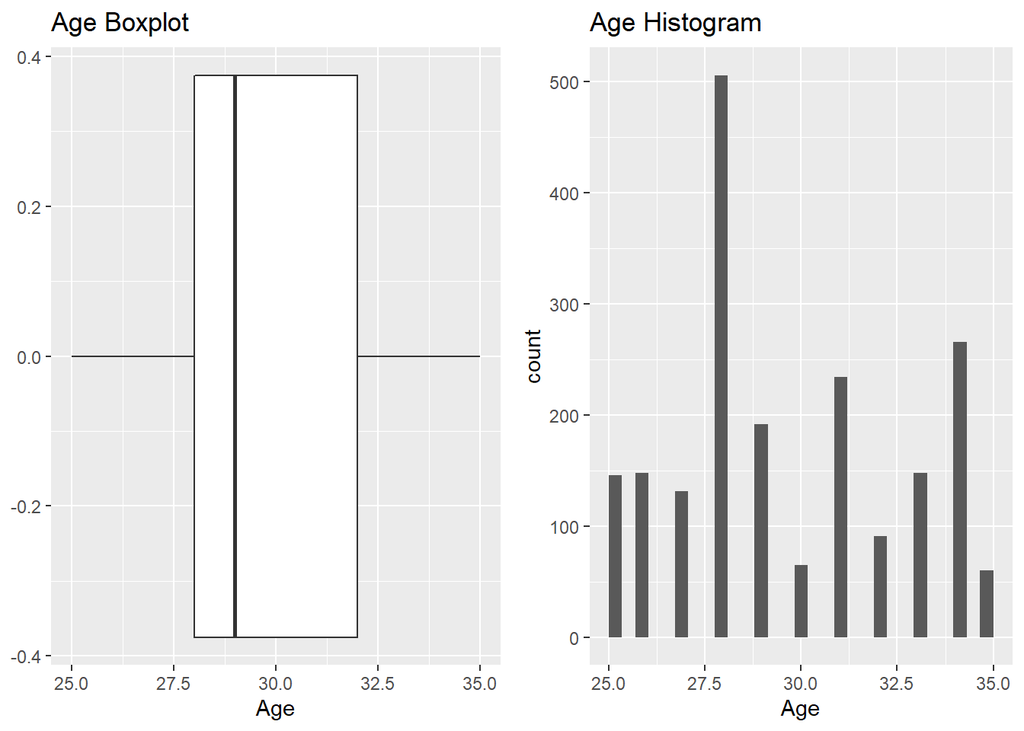

```r
# distribution
age.boxplot <- ggplot(travel,aes(Age)) +
      geom_boxplot(outlier.color = "red")+
      labs(title="Age Boxplot")
age.histo <- ggplot(travel,aes(Age)) +
      geom_histogram()+
      labs(title="Age Histogram")
grid.arrange(age.boxplot,age.histo,nrow=1)
```

##### Income

```r
#mean
Income.describe <- describe(travel$AnnualIncome)
Income.describe
```

```
##    vars    n   mean       sd median  trimmed    mad   min     max   range skew
## X1    1 1987 932763 376855.7  9e+05 929981.1 444780 3e+05 1800000 1500000 0.08
##    kurtosis      se
## X1    -1.02 8454.27
```

```r
#mode
Income.mode <- mode(travel$AnnualIncome)
Income.mode
```

```
## [1] 800000
```

```r
#quantiles
Income.quantiles <- quantile(travel$AnnualIncome)
Income.quantiles
```

```
##      0%     25%     50%     75%    100%
##  300000  600000  900000 1250000 1800000
```

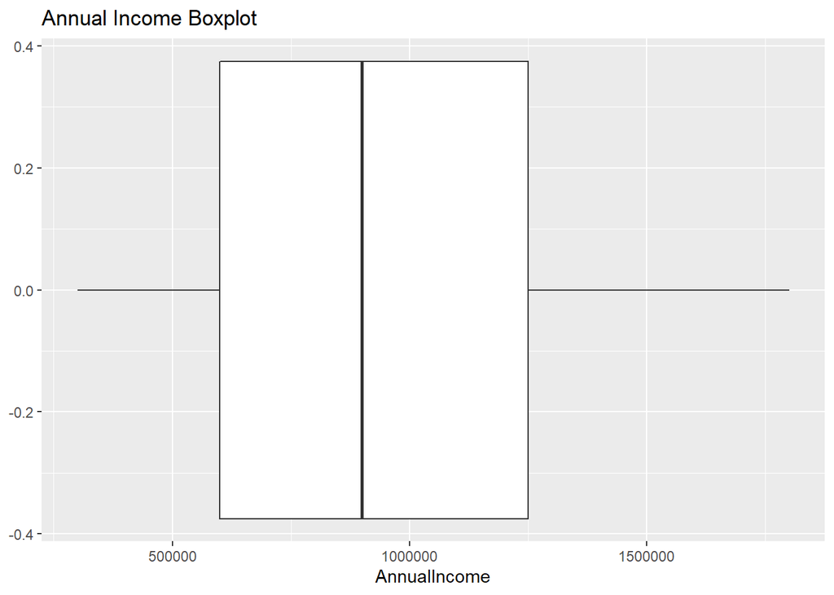

```r
#boxplot distibution
ggplot(travel,aes(AnnualIncome)) +
  geom_boxplot(outlier.color = "red")+
  labs(title="Annual Income Boxplot")
```

##### Family Members

```r
#mean
Family.describe <- describe(travel$FamilyMembers)
Family.describe
```

```
##    vars    n mean   sd median trimmed  mad min max range skew kurtosis   se
## X1    1 1987 4.75 1.61      5    4.64 1.48   2   9     7 0.56    -0.09 0.04
```

```r
#mode
Family.mode <- mode(travel$FamilyMembers)
Family.mode
```

```
## [1] 4
```

```r
#quantiles
Family.quantiles <- quantile(travel$FamilyMembers)
Family.quantiles
```

```
##   0%  25%  50%  75% 100%
##    2    4    5    6    9
```

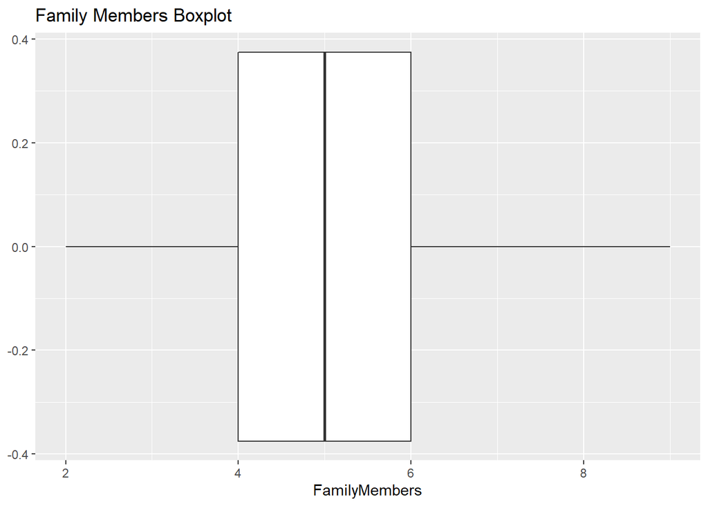

```r
#distribution
ggplot(travel,aes(FamilyMembers)) +
  geom_boxplot(outlier.color = "red")+
  labs(title="Family Members Boxplot")
```

#### Categorical Columns

##### Frequent flyer

```r
#mode
frequent.mode <- mode(travel$FrequentFlyer)
frequent.mode
```

```
## [1] No
## Levels: No Yes
```

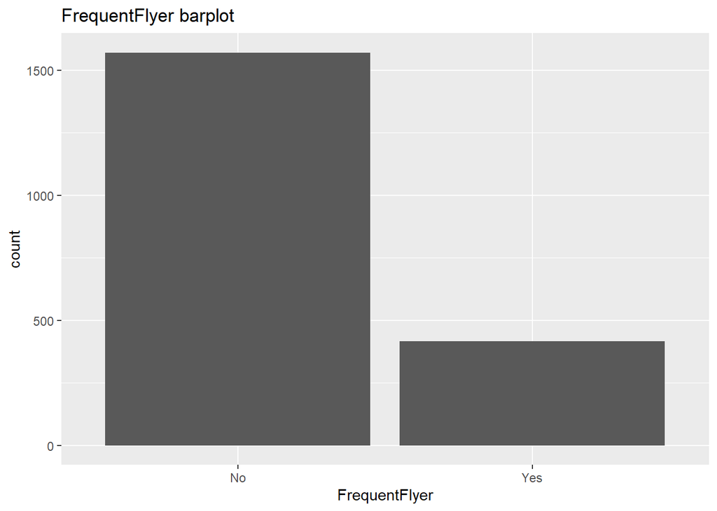

```r
#bar plot
frequent.barplot <- ggplot(travel,aes(FrequentFlyer)) +
  geom_bar(stat="count")+
  labs(title="FrequentFlyer barplot")
frequent.barplot
```

##### Employment Type

```r
#mode
employment.mode <- mode(travel$Employment.Type)
employment.mode
```

```
## [1] Private Sector/Self Employed
## Levels: Government Sector Private Sector/Self Employed
```

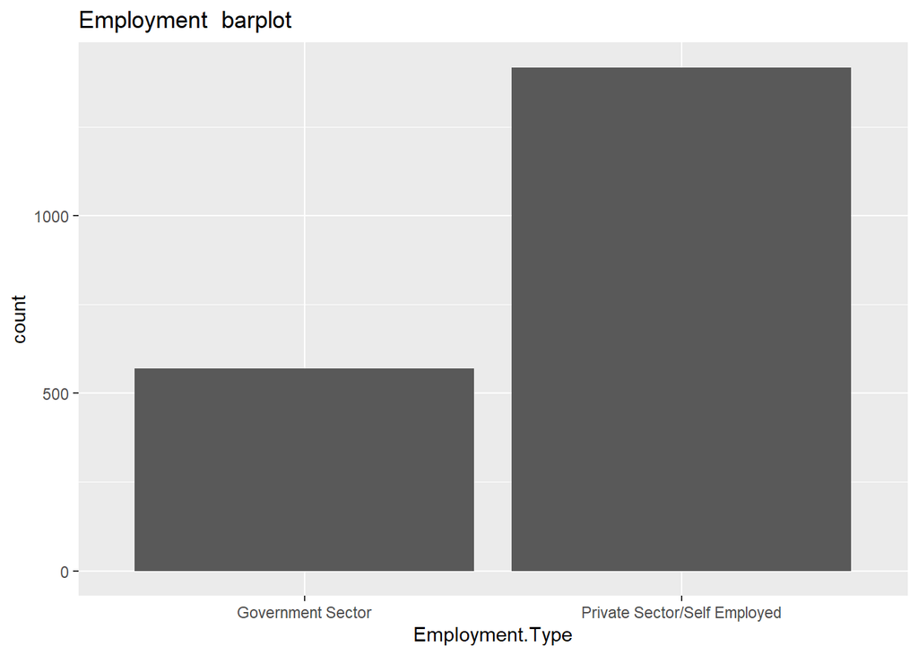

```r
#bar plot
employment.barplot <- ggplot(travel,aes(Employment.Type)) +
  geom_bar(stat="count")+
  labs(title="Employment  barplot")
employment.barplot
```

##### Ever Traveled Abroad

```r
#mode
travel.mode <- mode(travel$EverTravelledAbroad)
travel.mode
```

```
## [1] No
## Levels: No Yes
```

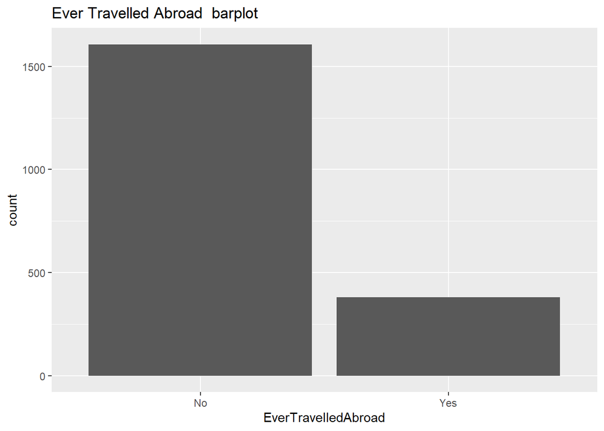

```r
#bar plot
travel.barplot <- ggplot(travel,aes(EverTravelledAbroad)) +
  geom_bar(stat="count")+
  labs(title="Ever Travelled Abroad  barplot")
travel.barplot
```

##### Employment Type

```r
#mode
employment.mode <- mode(travel$Employment.Type)
employment.mode
```

```
## [1] Private Sector/Self Employed
## Levels: Government Sector Private Sector/Self Employed
```

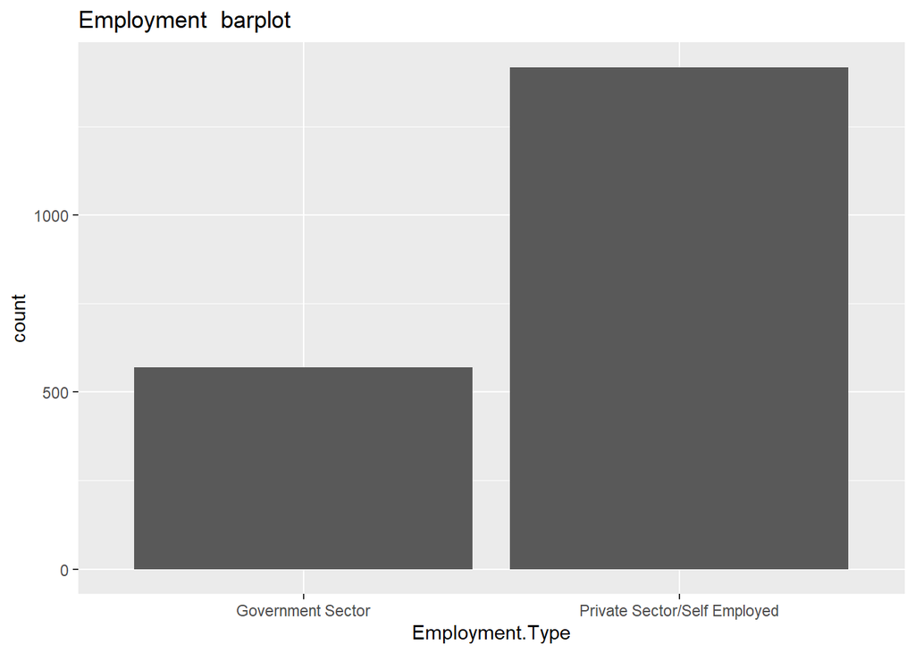

```r
#bar plot
employment.barplot <- ggplot(travel,aes(Employment.Type)) +
  geom_bar(stat="count")+
  labs(title="Employment  barplot")
employment.barplot
```

##### Graduate or not

```r
#mode
graduate.mode <-mode(travel$GraduateOrNot)
graduate.mode
```

```
## [1] Yes
## Levels: No Yes
```

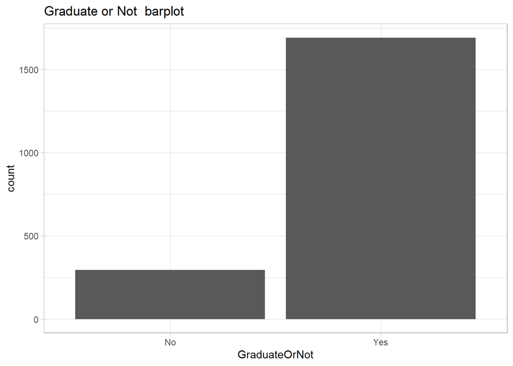

```r
#bar plot
graduate.barplot <- ggplot(travel,aes(GraduateOrNot),fill=dose) +
  geom_bar(stat="count")+
  labs(title="Graduate or Not  barplot") + theme_light()
graduate.barplot
```

##### Travel Insurance

```r
#mode
travel.mode <-mode(travel$TravelInsurance)
travel.mode
```

```
## [1] FALSE
## Levels: FALSE TRUE
```

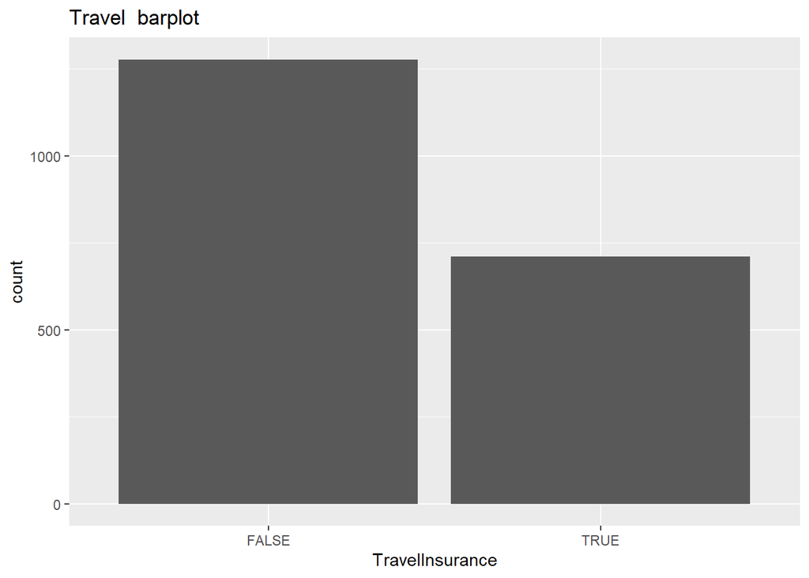

```r
#bar plot
travel.barplot <- ggplot(travel,aes(TravelInsurance)) +
  geom_bar(stat="count")+
  labs(title="Travel  barplot")
travel.barplot
```

##### Chronic Diseases

```r
#mode
chronic.mode <-mode(travel$ChronicDiseases)
chronic.mode
```

```
## [1] FALSE
## Levels: FALSE TRUE
```

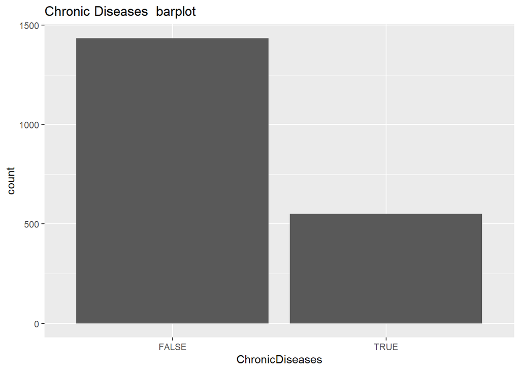

```r
#barplot
chronic.barplot <- ggplot(travel,aes(ChronicDiseases)) +
  geom_bar(stat="count")+
  labs(title="Chronic Diseases  barplot")
chronic.barplot
```

### Bi-variate Analysis

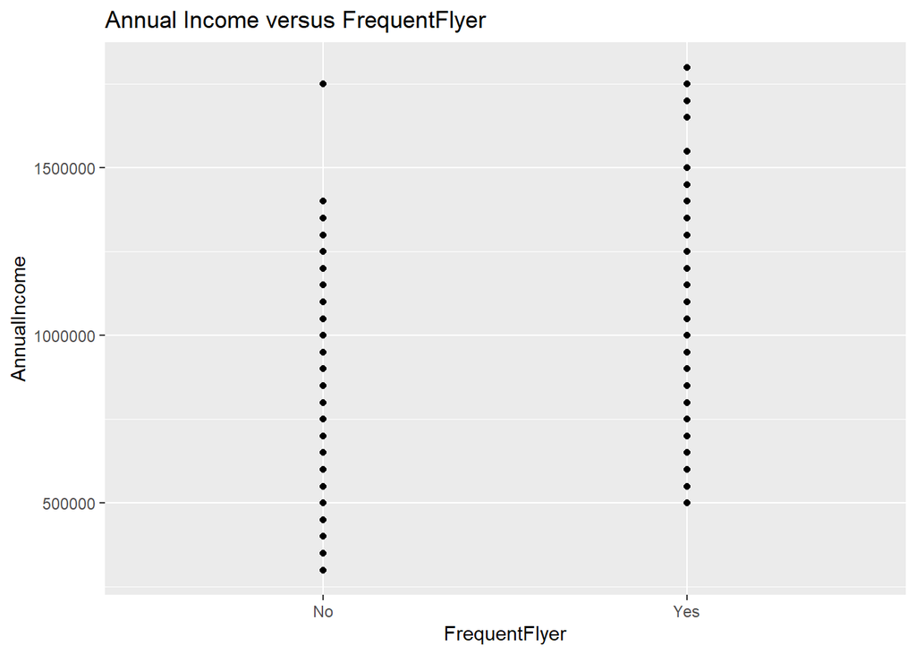

```r
sp <- ggplot(travel,aes(y=AnnualIncome,x=FrequentFlyer))+
  geom_point()+labs(title="Annual Income versus FrequentFlyer")

sp + scale_color_gradientn(colors=rainbow(5))
```

From our scatterplot we can see that the the people with a higher income are the ones who are most frequent flyers.

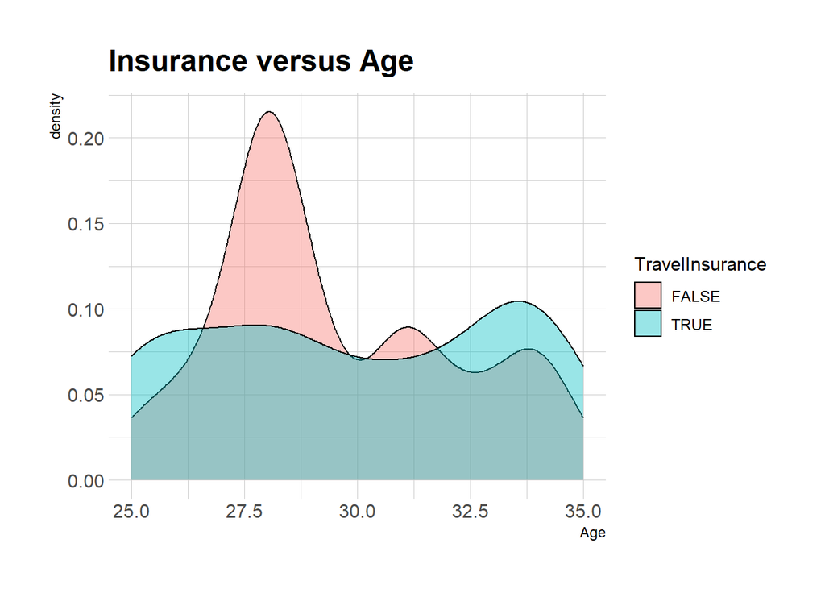

```r
ggplot(travel,aes(Age,fill=TravelInsurance,group=TravelInsurance))+
  geom_density(adjust=1.5,alpha = 0.4)+labs(title="Insurance versus Age")+
  theme_ipsum()
```

At 25, there are more people taking the cover. At 28, a lot more people opt not to take the cover. It could be attributed to the ending of parental insurance cover and since many people are starting families at this age they could choose to not take the cover(median age for first birth in India is 25- 49 years).

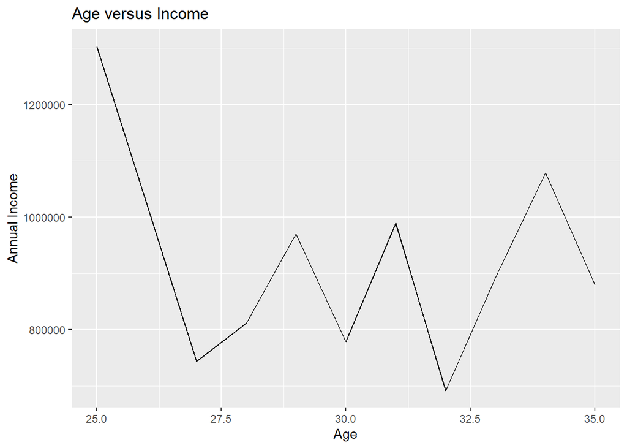

```r
df<- aggregate(AnnualIncome~Age,data=travel, mean)

ggplot(data=df, aes(y=AnnualIncome,x=Age))+
  geom_line()+
  xlab(label="Age")+
  ylab(label="Annual Income")+
  labs(title="Age versus Income")
```

At 25 years they are paid more, with a sharp decline at 27 years it then fluctuates from 27 to 35 years

[output not shown]

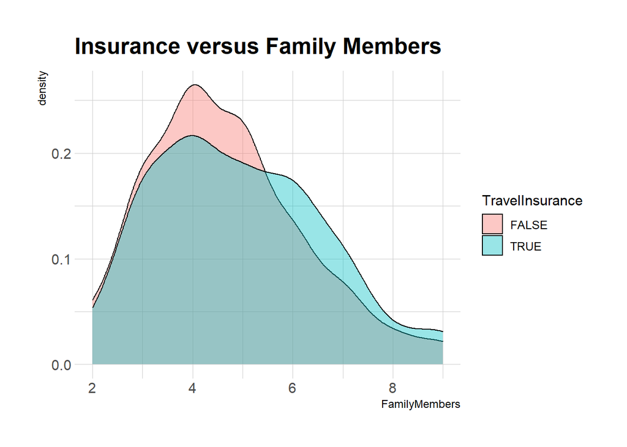

```r
ggplot(travel,aes(FamilyMembers,fill=TravelInsurance,group=TravelInsurance))+
  geom_density(adjust=1.5,alpha = 0.4)+labs(title="Insurance versus Family Members")+
  theme_ipsum()
```

For 2 and 3 family sizes, there are a roughly equal number of people taking and rejecting the cover. At 4, more people are not taking the insurance cover then around 5 to 9 more customers are taking the cover.

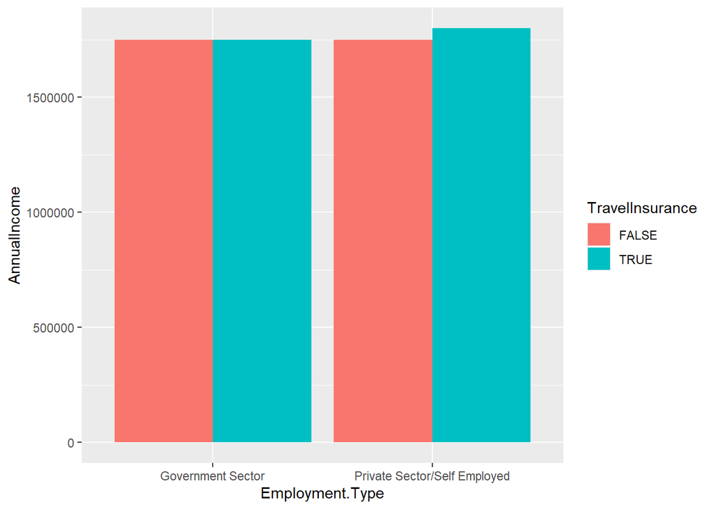

```r
ggplot(data=travel, aes(y=AnnualIncome,x=Employment.Type,fill=TravelInsurance))+
  geom_bar(position="dodge",stat="identity")
```

```r
cor(travel[, c(1, 4, 5)])
```

```
##                       Age AnnualIncome FamilyMembers
## Age            1.00000000  -0.02010149    0.02740866
## AnnualIncome  -0.02010149   1.00000000   -0.01536739
## FamilyMembers  0.02740866  -0.01536739    1.00000000
```

## Implementing the solution

### Decision Tree

```r
# getting the number of observations in the higher class

table(travel$TravelInsurance)
```

```
##
## FALSE  TRUE
##  1277   710
```

```r
# sampling using the value obtained

under.sample.d <- ovun.sample(TravelInsurance~., data = travel, method = "under", N =1420)$data
table(under.sample.d$TravelInsurance)
```

```
##
## FALSE  TRUE
##   710   710
```

```r
set.seed(123)
shuffle_index <- sample(1:nrow(travel))
travel.d <- under.sample.d[shuffle_index, ]
head(under.sample.d)
```

```
##   Age              Employment.Type GraduateOrNot AnnualIncome FamilyMembers
## 1  34 Private Sector/Self Employed           Yes       500000             5
## 2  26 Private Sector/Self Employed           Yes      1500000             7
## 3  32            Government Sector           Yes       800000             6
## 4  28 Private Sector/Self Employed           Yes       550000             8
## 5  31 Private Sector/Self Employed           Yes      1100000             4
## 6  28            Government Sector           Yes       300000             6
##   ChronicDiseases FrequentFlyer EverTravelledAbroad TravelInsurance
## 1           FALSE           Yes                 Yes           FALSE
## 2           FALSE           Yes                 Yes           FALSE
## 3           FALSE           Yes                  No           FALSE
## 4           FALSE            No                  No           FALSE
## 5            TRUE            No                  No           FALSE
## 6           FALSE            No                  No           FALSE
```

```r
# split
set.seed(3456)
ratio <- createDataPartition(under.sample.d$TravelInsurance, p=.8, list=FALSE)
train.d <- under.sample.d[ratio, ]
test.d <-under.sample.d[-ratio, ]
labels.d <- test.d$TravelInsurance
```

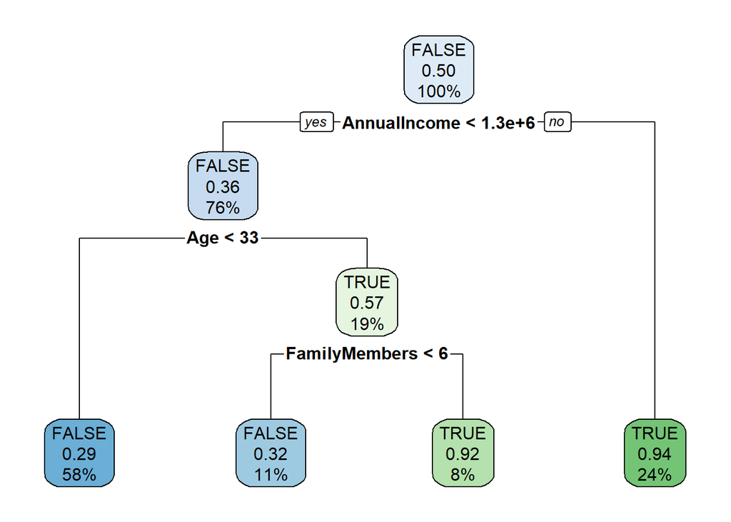

```r
model <- rpart(TravelInsurance ~ .,
               data = train.d,
               method ='class'
               )
rpart.plot(model, extra = 106)
```

```r
summary(model)
```

```
## Call:
## rpart(formula = TravelInsurance ~ ., data = train.d, method = "class")
##   n= 1136
##
##           CP nsplit rel error    xerror       xstd
## 1 0.41725352      0 1.0000000 1.0897887 0.02954970
## 2 0.06690141      1 0.5827465 0.5862676 0.02701111
## 3 0.01000000      3 0.4489437 0.4595070 0.02496243
##
## Variable importance
##        AnnualIncome EverTravelledAbroad                 Age       FamilyMembers
##                  42                  27                  13                  11
##       FrequentFlyer
##                   6
##
## Node number 1: 1136 observations,    complexity param=0.4172535
##   predicted class=FALSE  expected loss=0.5  P(node) =1
##     class counts:   568   568
##    probabilities: 0.500 0.500
##   left son=2 (869 obs) right son=3 (267 obs)
##   Primary splits:
##       AnnualIncome        < 1325000 to the left,  improve=137.50360, (0 missing)
##       EverTravelledAbroad splits as  LR,          improve= 88.06240, (0 missing)
##       FrequentFlyer       splits as  LR,          improve= 32.71704, (0 missing)
##       Age                 < 32.5    to the left,  improve= 18.63772, (0 missing)
##       Employment.Type     splits as  LR,          improve= 16.19143, (0 missing)
##   Surrogate splits:
##       EverTravelledAbroad splits as  LR,          agree=0.917, adj=0.648, (0 split)
##       FrequentFlyer       splits as  LR,          agree=0.801, adj=0.154, (0 split)
##       Age                 < 26.5    to the right, agree=0.797, adj=0.135, (0 split)
##
## Node number 2: 869 observations,    complexity param=0.06690141
##   predicted class=FALSE  expected loss=0.3636364  P(node) =0.7649648
##     class counts:   553   316
##    probabilities: 0.636 0.364
##   left son=4 (655 obs) right son=5 (214 obs)
##   Primary splits:
##       Age             < 32.5    to the left,  improve=25.3117500, (0 missing)
##       AnnualIncome    < 425000  to the left,  improve=11.0121200, (0 missing)
##       FamilyMembers   < 5.5     to the left,  improve= 9.6250890, (0 missing)
```

[output cut: 23 more lines]

```
##       AnnualIncome        < 1150000 to the left,  improve= 1.4969450, (0 missing)
##       FrequentFlyer       splits as  LR,          improve= 0.4337581, (0 missing)
##       ChronicDiseases     splits as  RL,          improve= 0.3154563, (0 missing)
##   Surrogate splits:
##       AnnualIncome < 450000  to the right, agree=0.584, adj=0.011, (0 split)
##
## Node number 10: 124 observations
##   predicted class=FALSE  expected loss=0.3225806  P(node) =0.1091549
##     class counts:    84    40
##    probabilities: 0.677 0.323
##
## Node number 11: 90 observations
##   predicted class=TRUE   expected loss=0.07777778  P(node) =0.07922535
##     class counts:     7    83
##    probabilities: 0.078 0.922
```

```r
#making predictions
pred.b <- predict(model,newdata = test.d[,-9])



pred.classes <- ifelse(argmax(pred.b, row=TRUE)==1, FALSE, TRUE)
pred.classes <- factor(pred.classes)

# confusion matrix
confusionMatrix(pred.classes,test.d$TravelInsurance, positive = "TRUE")
```

```
## Confusion Matrix and Statistics
##
##           Reference
## Prediction FALSE TRUE
##      FALSE   138   57
##      TRUE      4   85
##
##                Accuracy : 0.7852
##                  95% CI : (0.7328, 0.8315)
##     No Information Rate : 0.5
##     P-Value [Acc > NIR] : < 2.2e-16
##
##                   Kappa : 0.5704
##
##  Mcnemar's Test P-Value : 2.777e-11
##
##             Sensitivity : 0.5986
##             Specificity : 0.9718
##          Pos Pred Value : 0.9551
##          Neg Pred Value : 0.7077
##              Prevalence : 0.5000
##          Detection Rate : 0.2993
##    Detection Prevalence : 0.3134
##       Balanced Accuracy : 0.7852
##
##        'Positive' Class : TRUE
##
```

```r
F1_Score(pred.classes,test.d$TravelInsurance)
```

```
## [1] 0.8189911
```

```r
Precision(pred.classes, test.d$TravelInsurance)
```

```
## [1] 0.971831
```

```r
Recall(pred.classes, test.d$TravelInsurance)
```

```
## [1] 0.7076923
```

The F1-score which should be a balance of both recall and precision is surprisingly high. However, the recall is relatively low.

### Preprocessing

```r
travel$Employment.Type <- gsub("Government Sector", 0, travel$Employment.Type)
travel$Employment.Type <- gsub("Private Sector/Self Employed", 1, travel$Employment.Type)
travel$Employment.Type <- as.factor(travel$Employment.Type)

travel$GraduateOrNot <- gsub("Yes", 0, travel$GraduateOrNot)
travel$GraduateOrNot <- gsub("No", 1, travel$GraduateOrNot)
travel$GraduateOrNot <- as.factor(travel$GraduateOrNot)

travel$FrequentFlyer <- gsub("Yes", 1, travel$FrequentFlyer)
travel$FrequentFlyer <- gsub("No", 0, travel$FrequentFlyer)
travel$FrequentFlyer <- as.factor(travel$FrequentFlyer)

travel$EverTravelledAbroad <- gsub("Yes", 1, travel$EverTravelledAbroad)
travel$EverTravelledAbroad <- gsub("No", 0, travel$EverTravelledAbroad)
travel$EverTravelledAbroad <- as.factor(travel$EverTravelledAbroad)

# chronic disease
travel$ChronicDiseases <- gsub(FALSE, 0, travel$ChronicDiseases)
travel$ChronicDiseases <- gsub(TRUE, 1, travel$ChronicDiseases)
travel$ChronicDiseases <- as.factor(travel$ChronicDiseases)

# travel insurance
travel$TravelInsurance <- gsub(FALSE, 0, travel$TravelInsurance)
travel$TravelInsurance <- gsub(TRUE, 1, travel$TravelInsurance)
travel$TravelInsurance <- as.factor(travel$TravelInsurance)
```

```r
# getting the number of observations in the higher class

table(travel$TravelInsurance)
```

```
##
##    0    1
## 1277  710
```

```r
# sampling using the value obtained

under.sample <- ovun.sample(TravelInsurance~., data = travel, method = "under", N =1420)$data
table(under.sample$TravelInsurance)
```

```
##
##   0   1
## 710 710
```

```r
# normalization function
nor <-function(x) {(x -min(x))/(max(x)-min(x))}

# normalizing the data
travel_nor <- as.data.frame(mapply(under.sample[,c(1,4,5)], FUN =  nor))

# adding categorical columns
travel_nor$EmploymentType <- under.sample$Employment.Type
travel_nor$GraduateOrNot <- under.sample$GraduateOrNot
travel_nor$FrequentFlyer <- under.sample$FrequentFlyer
travel_nor$EverTravelledAbroad <- under.sample$EverTravelledAbroad
travel_nor$ChronicDiseases <- under.sample$ChronicDiseases
travel_nor$TravelInsurance <- under.sample$TravelInsurance
```

```r
set.seed(123)
shuffle_index <- sample(1:nrow(travel_nor))
travel_nor <- travel_nor[shuffle_index, ]
head(travel_nor)
```

```
##     Age AnnualIncome FamilyMembers EmploymentType GraduateOrNot FrequentFlyer
## 415 0.6   0.06666667     0.7142857              0             0             0
## 463 0.9   0.13333333     0.4285714              1             0             0
## 179 0.4   0.50000000     0.4285714              1             0             0
## 526 0.6   0.06666667     0.1428571              0             1             0
## 195 0.8   0.73333333     0.8571429              1             0             0
## 938 0.5   0.30000000     0.1428571              1             1             0
##     EverTravelledAbroad ChronicDiseases TravelInsurance
## 415                   0               0               0
## 463                   0               0               0
## 179                   0               0               0
## 526                   0               0               0
## 195                   1               0               0
## 938                   0               1               1
```

```r
set.seed(3456)
ratio <- createDataPartition(travel_nor$TravelInsurance, p=.8, list=FALSE)
train <- travel_nor[ratio, ]
test <-travel_nor[-ratio, ]
train.labels <- train$TravelInsurance
test.labels <- test$TravelInsurance
```

### Logistic Regression

```r
logistic <- glm(TravelInsurance ~.,family=binomial(link="logit"), data=train)
logistic
```

```
##
## Call:  glm(formula = TravelInsurance ~ ., family = binomial(link = "logit"),
##     data = train)
##
## Coefficients:
##          (Intercept)                   Age          AnnualIncome
##              -2.1724                0.6244                2.0358
##        FamilyMembers       EmploymentType1        GraduateOrNot1
##               0.8342                0.1233                0.2353
##       FrequentFlyer1  EverTravelledAbroad1      ChronicDiseases1
##               0.4556                1.9593                0.1475
##
## Degrees of Freedom: 1135 Total (i.e. Null);  1127 Residual
## Null Deviance:       1575
## Residual Deviance: 1253  AIC: 1271
```

```r
summary(logistic)
```

```
##
## Call:
## glm(formula = TravelInsurance ~ ., family = binomial(link = "logit"),
##     data = train)
##
## Deviance Residuals:
##     Min       1Q   Median       3Q      Max
## -2.3579  -0.9483  -0.1250   0.9944   1.9659
##
## Coefficients:
##                      Estimate Std. Error z value Pr(>|z|)
## (Intercept)           -2.1724     0.2517  -8.631  < 2e-16 ***
## Age                    0.6244     0.2331   2.678   0.0074 **
## AnnualIncome           2.0358     0.3305   6.159 7.31e-10 ***
## FamilyMembers          0.8342     0.2985   2.794   0.0052 **
## EmploymentType1        0.1233     0.1638   0.752   0.4518
## GraduateOrNot1         0.2353     0.1958   1.202   0.2294
## FrequentFlyer1         0.4556     0.1811   2.516   0.0119 *
## EverTravelledAbroad1   1.9593     0.2263   8.656  < 2e-16 ***
## ChronicDiseases1       0.1475     0.1530   0.964   0.3350
## ---
## Signif. codes:  0 '***' 0.001 '**' 0.01 '*' 0.05 '.' 0.1 ' ' 1
##
## (Dispersion parameter for binomial family taken to be 1)
##
##     Null deviance: 1574.8  on 1135  degrees of freedom
## Residual deviance: 1253.0  on 1127  degrees of freedom
## AIC: 1271
##
## Number of Fisher Scoring iterations: 4
```

```r
logistic.probs <- predict(logistic,type = "response", newdata = test)

# Checking the first five probabilities
head(logistic.probs)
```

```
##      1142      1253       348      1017        26       211
## 0.9240324 0.2525662 0.2609930 0.8616475 0.3846540 0.4531265
```

```r
logistic.pred <- ifelse(logistic.probs > 0.5, 1, 0)

confusionMatrix(factor(logistic.pred), test$TravelInsurance, positive = "1")
```

```
## Confusion Matrix and Statistics
##
##           Reference
## Prediction   0   1
##          0 119  57
##          1  23  85
##
##                Accuracy : 0.7183
##                  95% CI : (0.6621, 0.7699)
##     No Information Rate : 0.5
##     P-Value [Acc > NIR] : 5.899e-14
##
##                   Kappa : 0.4366
##
##  Mcnemar's Test P-Value : 0.0002247
##
##             Sensitivity : 0.5986
##             Specificity : 0.8380
##          Pos Pred Value : 0.7870
##          Neg Pred Value : 0.6761
##              Prevalence : 0.5000
##          Detection Rate : 0.2993
##    Detection Prevalence : 0.3803
##       Balanced Accuracy : 0.7183
##
##        'Positive' Class : 1
##
```

```r
F1_Score(logistic.pred,test$TravelInsurance)
```

```
## [1] 0.7484277
```

```r
Precision(logistic.pred,test$TravelInsurance)
```

```
## [1] 0.8380282
```

```r
Recall(logistic.pred,test$TravelInsurance)
```

```
## [1] 0.6761364
```

### K Nearest Neighbors

```r
knn1 <- knn(train = train,
            test = test,
            cl = train$TravelInsurance,
            k = 10)


# confusion Matrix

confusionMatrix(knn1, test.labels, positive = "1")
```

```
## Confusion Matrix and Statistics
##
##           Reference
## Prediction   0   1
##          0 142   0
##          1   0 142
##
##                Accuracy : 1
##                  95% CI : (0.9871, 1)
##     No Information Rate : 0.5
##     P-Value [Acc > NIR] : < 2.2e-16
##
##                   Kappa : 1
##
##  Mcnemar's Test P-Value : NA
##
##             Sensitivity : 1.0
##             Specificity : 1.0
##          Pos Pred Value : 1.0
##          Neg Pred Value : 1.0
##              Prevalence : 0.5
##          Detection Rate : 0.5
##    Detection Prevalence : 0.5
##       Balanced Accuracy : 1.0
##
##        'Positive' Class : 1
##
```

```r
# finding optimum k
i = 1
k.optm = 1
for (i in 1:28){
 knn.mod <- knn(train=train, test=test, cl=train.labels, k=i)
 k.optm[i] <- 100 * sum(test.labels == knn.mod)/NROW(test.labels)
 k=i
 cat(k,'=',k.optm[i],'')
}
```

[output not shown]

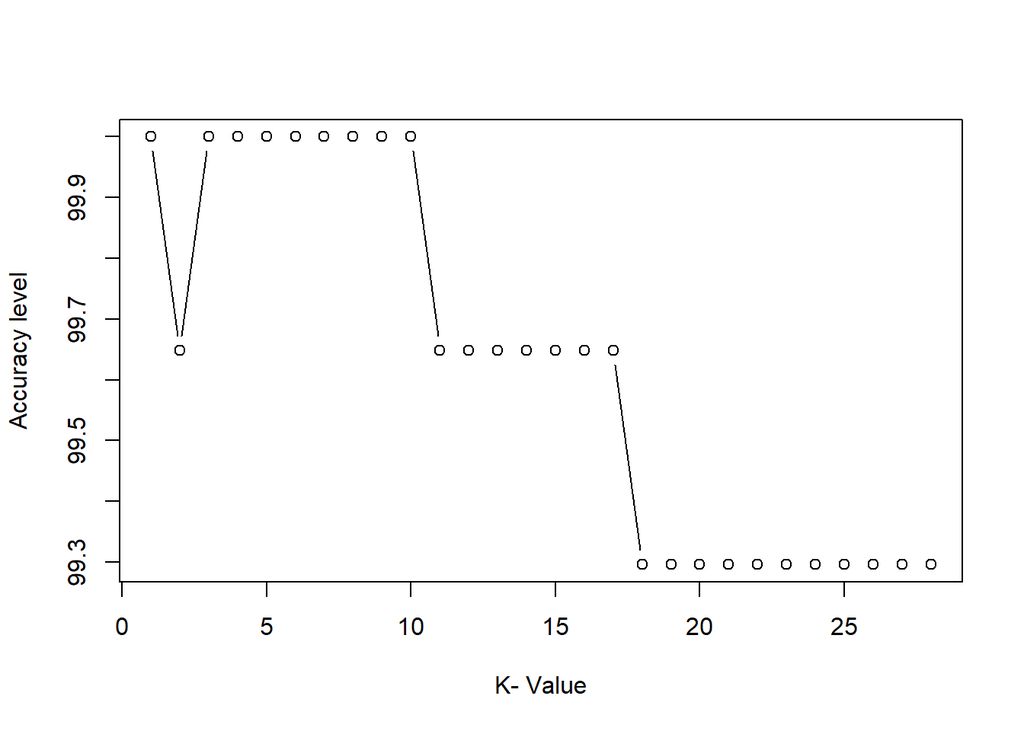

```r
plot(k.optm, type="b", xlab="K- Value",ylab="Accuracy level")
```

```r
trControl <- trainControl(method = "cv",
                          number = 5)


fit <- caret::train(TravelInsurance ~ .,
             method = "knn",
             tuneLength = 20,
             trControl = trControl,
             metric = "Accuracy",
             data = train,
             preProcess = c("center", "scale", "knnImpute"))
fit
```

```
## k-Nearest Neighbors
##
## 1136 samples
##    8 predictor
##    2 classes: '0', '1'
##
## Pre-processing: centered (8), scaled (8), nearest neighbor imputation (8)
## Resampling: Cross-Validated (5 fold)
## Summary of sample sizes: 909, 909, 908, 909, 909
## Resampling results across tuning parameters:
##
##   k   Accuracy   Kappa
##    5  0.7112914  0.4224712
##    7  0.7218680  0.4436458
##    9  0.7104027  0.4207563
##   11  0.7121570  0.4242858
##   13  0.7077595  0.4154936
##   15  0.7156851  0.4313662
##   17  0.7165507  0.4330854
##   19  0.7183129  0.4366177
##   21  0.7174318  0.4348920
##   23  0.7227065  0.4454657
##   25  0.7306322  0.4612742
##   27  0.7236031  0.4472219
##   29  0.7297782  0.4595517
##   31  0.7288855  0.4577714
##   33  0.7192016  0.4383896
##   35  0.7271196  0.4542346
##   37  0.7306245  0.4612503
##   39  0.7279774  0.4559333
##   41  0.7358992  0.4717814
##   43  0.7350259  0.4700501
##
## Accuracy was used to select the optimal model using the largest value.
## The final value used for the model was k = 41.
```

```r
pred.knn <- predict(fit,test[,-9])

confusionMatrix(pred.knn, test.labels, positive = "1")
```

```
## Confusion Matrix and Statistics
##
##           Reference
## Prediction   0   1
##          0 126  60
##          1  16  82
##
##                Accuracy : 0.7324
##                  95% CI : (0.6769, 0.783)
##     No Information Rate : 0.5
##     P-Value [Acc > NIR] : 1.181e-15
##
##                   Kappa : 0.4648
##
##  Mcnemar's Test P-Value : 8.121e-07
##
##             Sensitivity : 0.5775
##             Specificity : 0.8873
##          Pos Pred Value : 0.8367
##          Neg Pred Value : 0.6774
##              Prevalence : 0.5000
##          Detection Rate : 0.2887
##    Detection Prevalence : 0.3451
##       Balanced Accuracy : 0.7324
##
##        'Positive' Class : 1
##
```

#### Naive Bayes Model

```r
model <- naiveBayes(TravelInsurance~., data=train)


# making predictions

pred.nb <- predict(model, newdata=test)

# confusion matrix

confusionMatrix(pred.nb, test.labels, positive="1")
```

```
## Confusion Matrix and Statistics
##
##           Reference
## Prediction   0   1
##          0 116  59
##          1  26  83
##
##                Accuracy : 0.7007
##                  95% CI : (0.6438, 0.7534)
##     No Information Rate : 0.5
##     P-Value [Acc > NIR] : 5.334e-12
##
##                   Kappa : 0.4014
##
##  Mcnemar's Test P-Value : 0.0005187
##
##             Sensitivity : 0.5845
##             Specificity : 0.8169
##          Pos Pred Value : 0.7615
##          Neg Pred Value : 0.6629
##              Prevalence : 0.5000
##          Detection Rate : 0.2923
##    Detection Prevalence : 0.3838
##       Balanced Accuracy : 0.7007
##
##        'Positive' Class : 1
##
```

```r
caret::train(TravelInsurance~.,
             data= train,
             metric = "Accuracy",
             trControl  = trainControl(method="cv", number =10),
             method = "nb")
```

```
## Naive Bayes
##
## 1136 samples
##    8 predictor
##    2 classes: '0', '1'
##
## No pre-processing
## Resampling: Cross-Validated (10 fold)
## Summary of sample sizes: 1022, 1023, 1022, 1022, 1022, 1023, ...
## Resampling results across tuning parameters:
##
##   usekernel  Accuracy   Kappa
##   FALSE      0.6954433  0.3908336
##    TRUE      0.7130337  0.4260976
##
## Tuning parameter 'fL' was held constant at a value of 0
## Tuning
##  parameter 'adjust' was held constant at a value of 1
## Accuracy was used to select the optimal model using the largest value.
## The final values used for the model were fL = 0, usekernel = TRUE and adjust
##  = 1.
```

```r
nb2 <- naiveBayes(TravelInsurance~., data=train,
           fL = 0,
           useKernel = TRUE,
           adjust = 1)

pred.nb2 <- predict(nb2, newdata = test)
confusionMatrix(pred.nb2, test.labels, positive = "1")
```

```
## Confusion Matrix and Statistics
##
##           Reference
## Prediction   0   1
##          0 116  59
##          1  26  83
##
##                Accuracy : 0.7007
##                  95% CI : (0.6438, 0.7534)
##     No Information Rate : 0.5
##     P-Value [Acc > NIR] : 5.334e-12
##
##                   Kappa : 0.4014
##
##  Mcnemar's Test P-Value : 0.0005187
##
##             Sensitivity : 0.5845
##             Specificity : 0.8169
##          Pos Pred Value : 0.7615
##          Neg Pred Value : 0.6629
##              Prevalence : 0.5000
##          Detection Rate : 0.2923
##    Detection Prevalence : 0.3838
##       Balanced Accuracy : 0.7007
##
##        'Positive' Class : 1
##
```

```r
F1_Score(pred.nb2,test.labels)
```

```
## [1] 0.7318612
```

```r
Precision(pred.nb2, test.labels)
```

```
## [1] 0.8169014
```

```r
Recall(pred.nb2, test.labels)
```

```
## [1] 0.6628571
```

Attained an F1-Score of 73.2% , Precision score was 81.69% and Recall score was 66.28%.

### Unsupervised Learning

#### Kmeans Clustering

```r
df <-travel_nor
df$EmploymentType <- as.numeric(df$EmploymentType)
df$ChronicDiseases <- as.numeric(df$ChronicDiseases)
df$GraduateOrNot <- as.numeric(df$GraduateOrNot)
df$FrequentFlyer <- as.numeric(df$FrequentFlyer)
df$EverTravelledAbroad <- as.numeric(df$EverTravelledAbroad)
```

```r
k2 <- kmeans(df[, -9], centers = 2, nstart = 25)
k2$size
```

```
## [1] 467 953
```

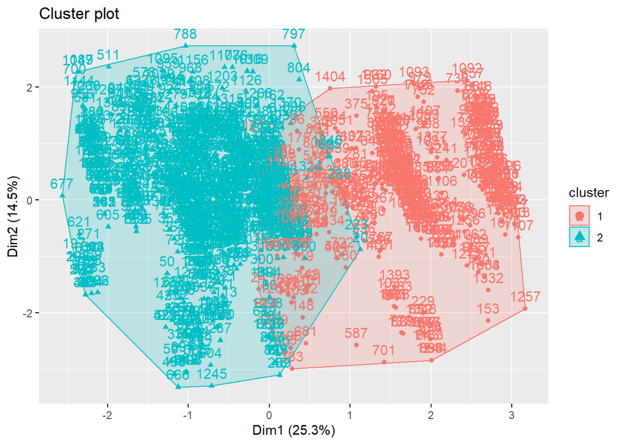

```r
fviz_cluster(k2, data=df[ -9])
```

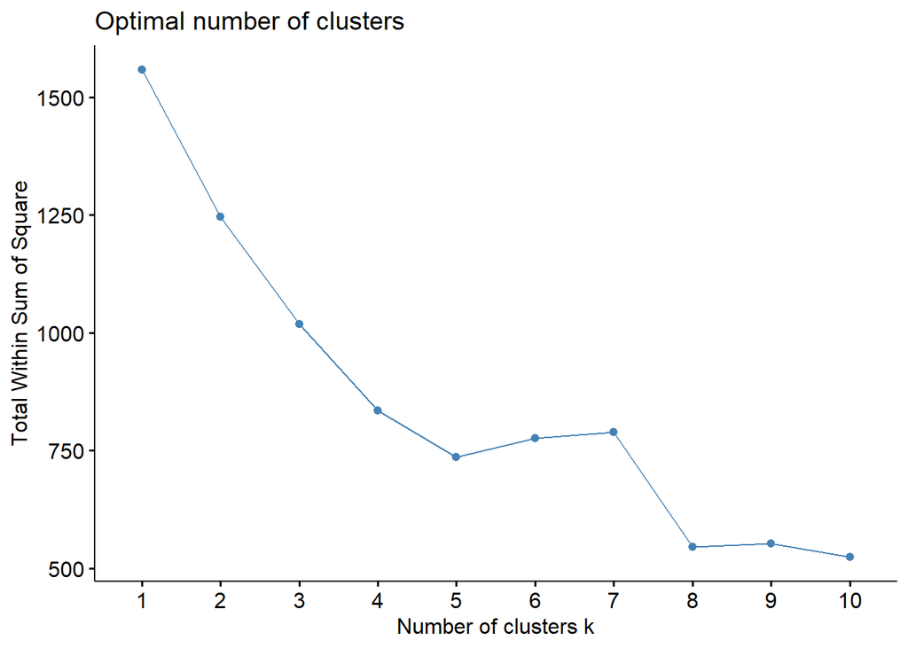

```r
fviz_nbclust(df[,-9], kmeans, method="wss")
```

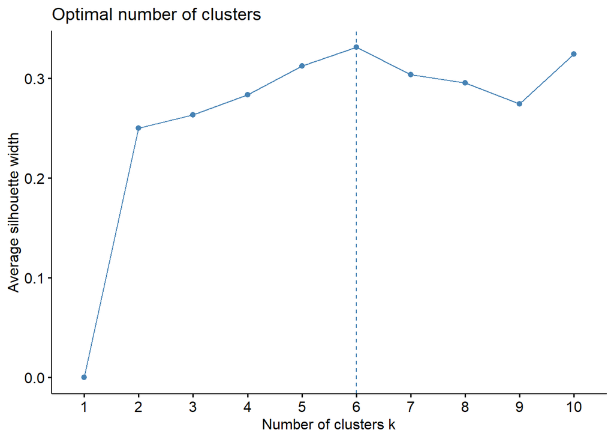

```r
fviz_nbclust(df[,-9], kmeans, method="silhouette")
```

```r
gap_stat <- clusGap(df[,-9], FUN = kmeans, nstart = 25,
                    K.max = 10, B = 50)
```

[output not shown]

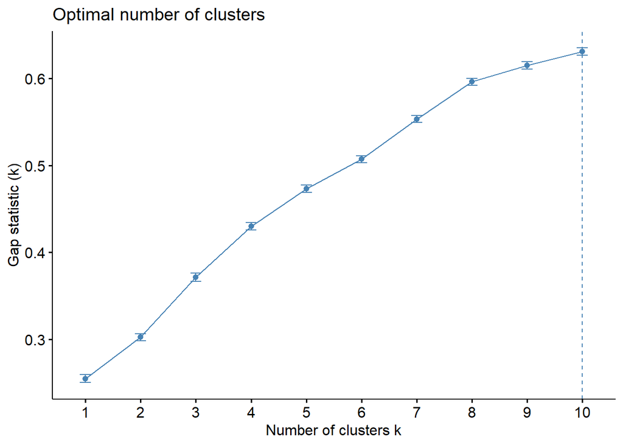

```r
fviz_gap_stat(gap_stat)
```

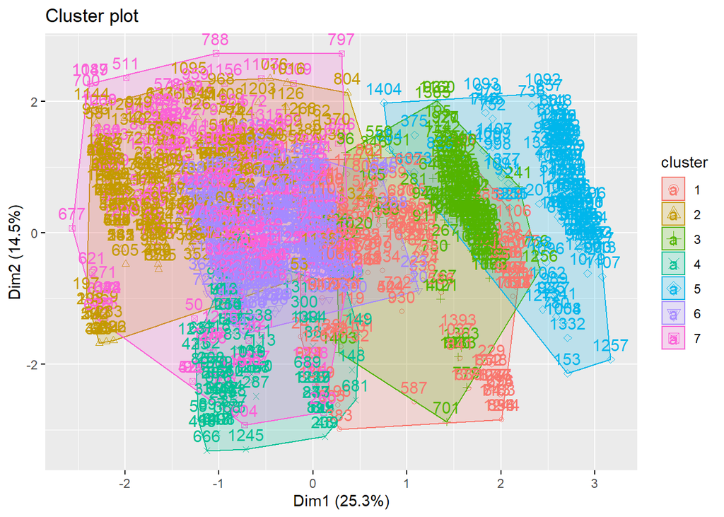

```r
k3 <- kmeans(df[,-9] ,centers = 7, nstart = 25)


# plotting the results
fviz_cluster(k3, data=df[ -9])
```

#### Hierarchical clustering

```r
ran <- sample(1:nrow(df),0.03 * nrow(df))

j <- df[ran,]
```

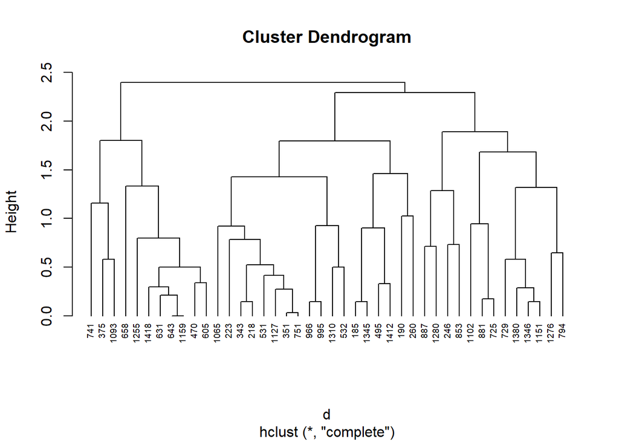

```r
# dissimilarity matrix
d <- dist(j[, -9], method="euclidean")

# hierarchical
hc1 <- hclust(d, method = "complete")

# plot dendogram
plot(hc1, cex = 0.6, hang = -1)
```

```r
# methods to assess
m <- c( "average", "single", "complete", "ward")

names(m) <- c( "average", "single", "complete", "ward")

# function to compute coefficient
ac <- function(x) {
  agnes(j, method = x)$ac
}

map_dbl(m,ac)
```

```
##   average    single  complete      ward
## 0.6813013 0.5221371 0.7694010 0.8914728
```

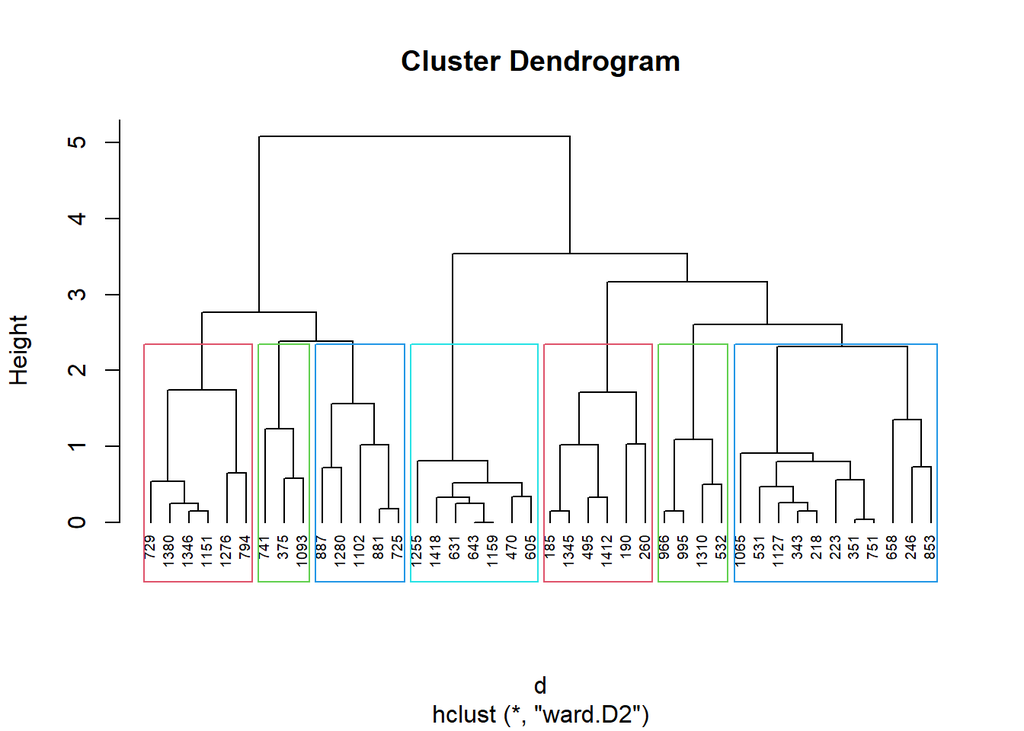

```r
# dissimilarity matrix
d <- dist(j[, -9], method="euclidean")

# hierarchical
hc1 <- hclust(d, method = "ward.D2")

# plot dendogram
plot(hc1, cex = 0.6, hang = -1)

rect.hclust(hc1, k = 7, border = 2:5)
```

```r
#colMeans(df)
sapply(df, class)
```

```
##                 Age        AnnualIncome       FamilyMembers      EmploymentType
##           "numeric"           "numeric"           "numeric"           "numeric"
##       GraduateOrNot       FrequentFlyer EverTravelledAbroad     ChronicDiseases
##           "numeric"           "numeric"           "numeric"           "numeric"
##     TravelInsurance
##            "factor"
```

## Challenging the Solution

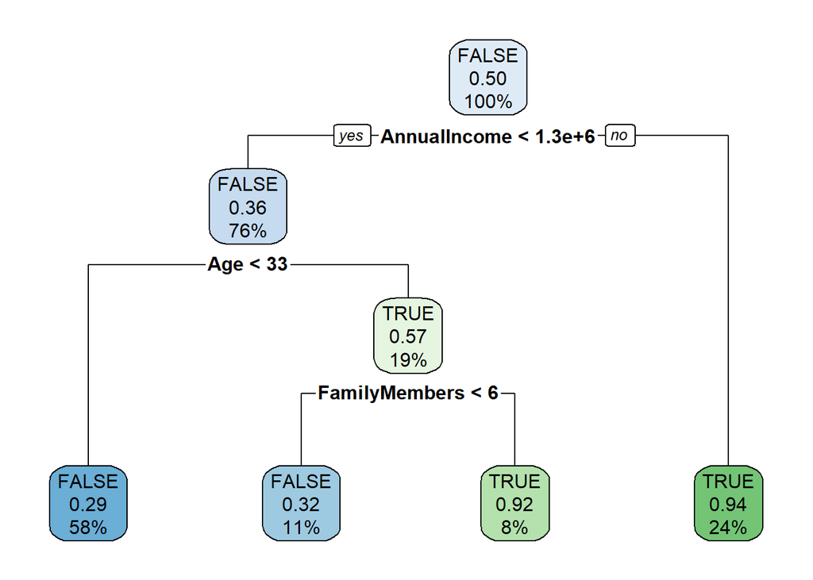

```r
prun <- rpart(TravelInsurance ~ .,
               data = train.d,
               method ='class',
              control = rpart.control(cp = 0, maxdepth = 8,minsplit = 100))

rpart.plot(prun, extra = 106)
```

```r
#making predictions
pred.prun <- predict(prun,newdata = test.d[,-9])



pred.cp <- ifelse(argmax(pred.prun, row=TRUE)==1, FALSE, TRUE)
pred.cp <- factor(pred.cp)

# confusion matrix
confusionMatrix(pred.cp,test.d$TravelInsurance, positive = "TRUE")
```

```
## Confusion Matrix and Statistics
##
##           Reference
## Prediction FALSE TRUE
##      FALSE   138   57
##      TRUE      4   85
##
##                Accuracy : 0.7852
##                  95% CI : (0.7328, 0.8315)
##     No Information Rate : 0.5
##     P-Value [Acc > NIR] : < 2.2e-16
##
##                   Kappa : 0.5704
##
##  Mcnemar's Test P-Value : 2.777e-11
##
##             Sensitivity : 0.5986
##             Specificity : 0.9718
##          Pos Pred Value : 0.9551
##          Neg Pred Value : 0.7077
##              Prevalence : 0.5000
##          Detection Rate : 0.2993
##    Detection Prevalence : 0.3134
##       Balanced Accuracy : 0.7852
##
##        'Positive' Class : TRUE
##
```

```r
F1_Score(pred.cp,test.d$TravelInsurance)
```

```
## [1] 0.8189911
```

```r
Precision(pred.cp, test.d$TravelInsurance)
```

```
## [1] 0.971831
```

```r
Recall(pred.cp, test.d$TravelInsurance)
```

```
## [1] 0.7076923
```

## Conclusions

From our bivariate analysis

Age versus Insurance plot - At 25, there are more people taking the cover. At 28, a lot more people opt not to take the cover. It could be attributed to the ending of parental insurance cover and since many people are starting families at this age they could choose to not take the cover(median age for first birth in India is 25- 49 years.

Annual Income and Age plot - At 25 years they are paid more, with a sharp decline at 27 years it then fluctuates from 27 to 35 years.

Family members versus insurance plot - For 2 and 3 family sizes, there are a roughly equal number of people taking and rejecting the cover. At 4, more people are not taking the insurance cover then around 5 to 9 more customers are taking the cover.

Annual Income versus FrequentFlyer plot - From our scatterplot we can see that the the people with a higher income are the ones who are most frequent flyers.

Employment Type versus Annual Income plot - In the government sector, there is an equal number of people taking and not taking the insurance cover whereas in the private sector people taking insurance are slightly higher than those not taking the cover. Moreover, those taking the insurance cover are also paid slightly more.

## Recommendations

- The following are our recommendations :
- To offer a family package alongside the individual packages considering the fact that people aged 26 to 30 seem to be having bigger priorities due to a growing number of dependents. This could either be from starting families or having relatives who are depending on their success.
- To create a more affordable package that targets the low income earners given that the data suggests that travel insurance might not be a priority to target this demographic.
- Create market awareness on the associated travelling risks and hence the need for travel insurance to the first time flyers which is a move that might increase the sales of the insurance package.
- Create a more encompassing medical scope in the package to include more chronic diseases given that the data shows a high count of people with an age of 27 to 29 have chronic diseases yet opt out of travel insurance.
- The company could put effort to build their brand awareness as a tour and travel agency so that they can increase their market acceptance.